# week 6 day 3 hw

# Load packages

```r
library(tidyverse)
library(janitor)
library(infer)
```

# Question 1

## Load the data again, clean_names(), and re-familiarise yourself with it

```r
ames <- read_csv(here::here("data/ames.csv")) %>%
  clean_names()
```

```r
dim(ames)
```

```
[1] 2930   82
```

# Question 2

## Investigate the distribution of lot_area. Is the distribution roughly normal? If not, what problems do you find?

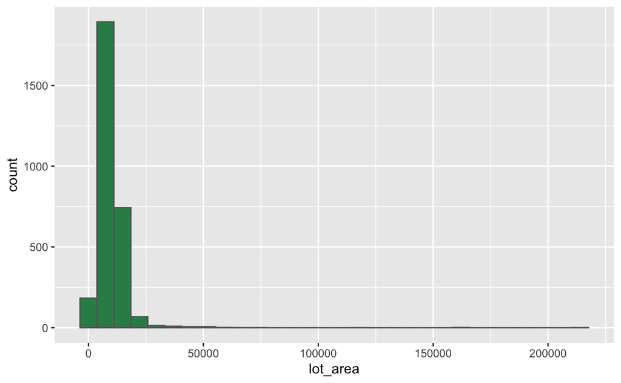

```r
lot_area_plot <- ames %>%
  ggplot(aes(x = lot_area)) +
  geom_histogram(colour = "grey40", fill = "seagreen", bins = 30)

lot_area_plot
```

**Solution**

No, lot_area does not appear to be normally distributed. The data appears very narrow and appears to be skewed to the right.

# Question 3

## Compute and visualise a bootstrap sampling distribution for the mean(lot_area) of the sold houses.

```r
bootstrap_sample_100
```

```
Response: lot_area (numeric)
```

| replicate | stat |
| --- | --- |
| 1 | 10437.341 |
| 2 | 10189.392 |
| 3 | 10094.112 |
| 4 | 10051.936 |
| 5 | 10184.781 |
| 6 | 9888.714 |
| 7 | 10233.273 |
| 8 | 10211.313 |
| 9 | 10198.518 |
| 10 | 10328.201 |

[output cut: 90 more lines]

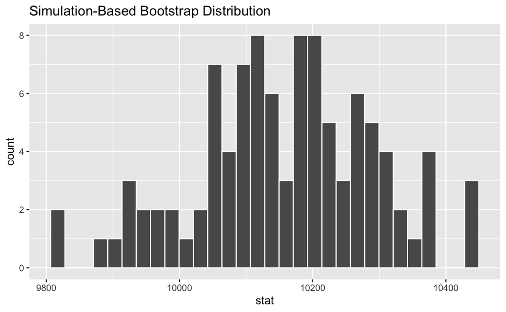

```r
bootstrap_sample_100_visual <- bootstrap_sample_100 %>%
  visualise(bins = 30)

bootstrap_sample_100_visual
```

**Interpretation**

From this plot we can visualise our bootstrap distribution and how it looks similar to a normal distribution.

# Question 4

```r
bootstrap_95_ci <- bootstrap_sample_100 %>%
  get_confidence_interval(level = 0.95, type = "percentile")

bootstrap_95_ci
```

| lower_ci | upper_ci |
| --- | --- |
| 9898.358 | 10408.25 |

**Interpretation**

We would expect that 95% of the time our population parameter to lie within the range of this confidence interval of 9898.358 - 10408.25.

# Question 5

## You would like to know the mean(lot_area) of the sold houses with higher confidence. Calculate the 99% CI for this variable (you can re-use your bootstrap distribution from above). Is it narrower or broader than the 95% CI? Does that make sense?

```r
bootstrap_99_ci <- bootstrap_sample_100 %>%
  get_confidence_interval(level = 0.99, type = "percentile")

bootstrap_99_ci
```

| lower_ci | upper_ci |
| --- | --- |
| 9818.529 | 10435.6 |

**Solution**

The 99% confidence interval is (slightly) broader than the 95% confidence intervall. This is to be expected since we would expect to capture more sample means within our interval, thus it should be broader.

# Question 6

## Calculate the point estimate of the mean(lot_area)

```r
point_estimate_lot_area <- bootstrap_sample_100 %>%
  summarise(mean = mean(stat))

point_estimate_lot_area
```

| mean |
| --- |
| 10157.43 |

**Interpretation**

Our point estimate of 10157.43 lies almost in the middle of our 95% and 99% confidence intervals which illustrates that we can be confident our bootstrap and point estimate are suitable estimates of the population parameter mean lot_area. (Well 95%/99% confident)